# The influence of weather and a pandemic on crime

### Install packages (if required)

```r
# set eval=TRUE if running script for the first time
if(!require("ggseas")) install.packages("ggseas")
if(!require("forecast")) install.packages("forecast")
if(!require("data.table")) install.packages("data.table")
if(!require("knitr")) install.packages("knitr")
if(!require("bigrquery")) install.packages("bigrquery")
if(!require("devtools")) install.packages("devtools")
if(!require("tsibble")) install.packages("tsibble")
if(!require("fable")) install.packages("fable")  # forecasting package of the tidyverse family
# devtools::install_github("rstats-db/bigrquery", force = TRUE)
```

### Load packages

```r
library(bigrquery)
library(ggplot2)
library(tidyr)
library(dplyr)
library(lubridate) # handle date information
library(readr) # read txt file with credentials
library(fable)
library(tsibble)
library(feasts)
library(ggpmisc) # plot R^2 in scatter plot
```

### Retrieve Google Cloud credentials

Retrieve Google Cloud project ID, which I store in an external file (not uploaded to github).

```r
# Set Google Cloud project ID here
project_name <- read_file("./GC_credentials.txt")
```

### Retrieve data with date information

TODO: Cache locally and only fetch additional (recent) data.

```r
counts_day <- read.csv("counts_day.csv")
head(counts_day)
```

|  | iucr | primary_type | description | date |
| --- | --- | --- | --- | --- |
| 1 | 2012 | NARCOTICS | MANU/DELIVER:COCAINE | 2008-06-29 14:30:00 |
| 2 | 2830 | OTHER OFFENSE | OBSCENE TELEPHONE CALLS | 2009-09-02 08:00:00 |
| 3 | 0841 | THEFT | FINANCIAL ID THEFT:$300 &UNDER | 2009-12-01 12:00:00 |
| 4 | 1153 | DECEPTIVE PRACTICE | FINANCIAL IDENTITY THEFT OVER $ 300 | 2009-03-15 12:00:00 |
| 5 | 1153 | DECEPTIVE PRACTICE | FINANCIAL IDENTITY THEFT OVER $ 300 | 2011-12-11 09:00:00 |
| 6 | 1153 | DECEPTIVE PRACTICE | FINANCIAL IDENTITY THEFT OVER $ 300 | 2015-11-12 15:00:00 |

```r
# format as date
counts_day$date <- as.Date(ymd_hms(counts_day$date))
head(counts_day)
```

|  | iucr | primary_type | description | date |
| --- | --- | --- | --- | --- |
| 1 | 2012 | NARCOTICS | MANU/DELIVER:COCAINE | 2008-06-29 |
| 2 | 2830 | OTHER OFFENSE | OBSCENE TELEPHONE CALLS | 2009-09-02 |
| 3 | 0841 | THEFT | FINANCIAL ID THEFT:$300 &UNDER | 2009-12-01 |
| 4 | 1153 | DECEPTIVE PRACTICE | FINANCIAL IDENTITY THEFT OVER $ 300 | 2009-03-15 |
| 5 | 1153 | DECEPTIVE PRACTICE | FINANCIAL IDENTITY THEFT OVER $ 300 | 2011-12-11 |
| 6 | 1153 | DECEPTIVE PRACTICE | FINANCIAL IDENTITY THEFT OVER $ 300 | 2015-11-12 |

In the dataframe, each row stands for one offense of a particular type, at a particular time. We add a column of “counts”, that for now is always one. This fascilitates summing up rows (e.g., by day) later on.

```r
counts_day$count <- rep(1,nrow(counts_day))
# sort by ascending date
counts_day <- counts_day %>% arrange(date)
```

```r
# group by day (across offense types)
counts_day <- tibble(counts_day)

daily_counts <- counts_day %>%
  group_by(date) %>%
  summarize(counts = sum(count))
head(daily_counts)
```

| date | counts |
| --- | --- |
| 2001-01-01 | 1820 |
| 2001-01-02 | 1143 |
| 2001-01-03 | 1151 |
| 2001-01-04 | 1166 |
| 2001-01-05 | 1267 |
| 2001-01-06 | 1290 |

### tsibble: time-sensitive tibble

1. Index is a variable with inherent ordering from past to present.
2. Key is a set of variables that define observational units over time.
3. Each observation should be uniquely identified by index and key.
4. Each observational unit should be measured at a common interval, if regularly spaced.

```r
# turn into time-sensitive tibble
# works like a normal tibble but tracks time (set by index)
daily_counts <- as_tsibble(daily_counts, index=date) %>% arrange(date)
```

## Time series analysis

Theory: Forecasting: Principles and Practice Rob J Hyndman and George Athanasopoulos Monash University, Australia Available at https://otexts.com/fpp3/

“a key step is knowing when something can be forecast accurately, and when forecasts will be no better than tossing a coin. Good forecasts capture the genuine patterns and relationships which exist in the historical data, but do not replicate past events that will not occur again. In this book, we will learn how to tell the difference between a random fluctuation in the past data that should be ignored, and a genuine pattern that should be modelled and extrapolated.”

Each time series has three components: 1) trend 2) seasonality 3) error

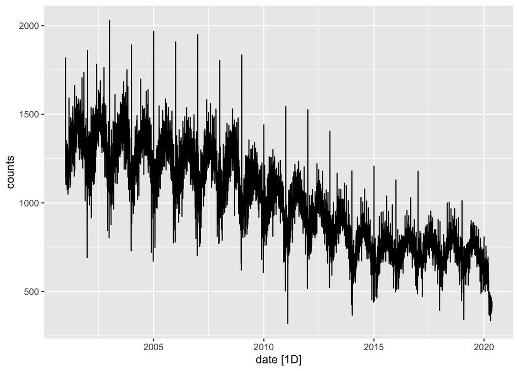

```r
# simple plot using the feasts package
daily_counts %>% autoplot(counts)
```

The autoplot shows a consistent negative trend and strong seasonality

Is this a multiplicative or additive time series? - interaction between general seasonality and the underlying trend - multiplicative time series: the components multiply; with de- or increasing trend, the amplitude of seasonal activity increases - additive time series: components additive to make up time series; with increasing trend, you still see roughly the same size peaks and troughs throughout the time series; often indexed time series where the absolute value is growing but changes stay relative

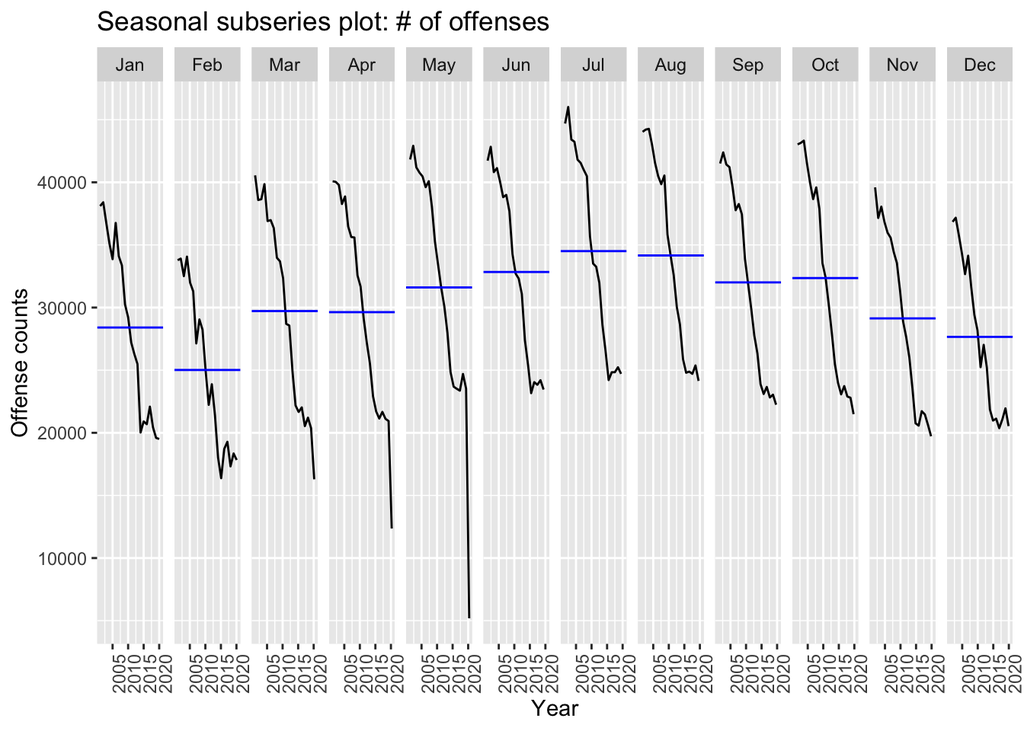

```r
daily_counts %>%
      index_by(year_month = ~ yearmonth(.)) %>% # monthly aggregates
  summarise(ttl_count = sum(counts, na.rm = TRUE)) %>%
  gg_subseries(ttl_count) +
    ylab("Offense counts") +
    xlab("Year") +
    ggtitle("Seasonal subseries plot: # of offenses")
```

Pull in weather data (TODO: either script or pull fresh from BigQuery, currently separate script)

```r
daily_weather <- read.csv("weather_day.csv", header=TRUE)
daily_weather$date <- as.Date(daily_weather$date)
```

Join the crime and weather data

```r
daily_crime <- left_join(daily_counts, daily_weather, by = "date")
```

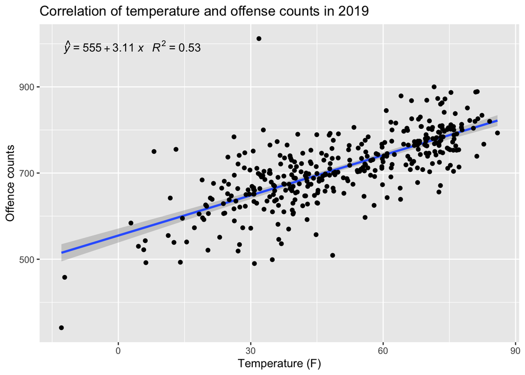

```r
year = 2019
daily_crime %>%
  filter(year(date) == year) %>%
  ggplot(aes(x = temperature, y = counts)) +
  ylab("Offence counts") + xlab("Temperature (F)") +
  ggtitle(paste("Correlation of temperature and offense counts in", year, sep=" ")) +
  geom_smooth(method = "lm") +
  stat_poly_eq(formula = y ~ x,
                eq.with.lhs = "italic(hat(y))~`=`~",
                aes(label = paste(..eq.label.., ..rr.label.., sep = "~~~")),
                parse = TRUE) +
  geom_point()
```

In ‘normal’ years, the number of offenses and temperature are correlated. Temperature explains more than half of the variation in offense counts (i.e., R^2 above 0.5).

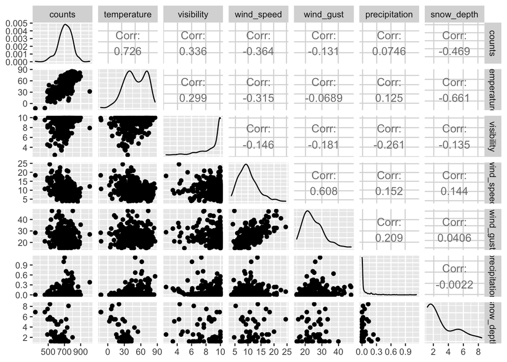

```r
year = 2019
daily_crime %>%
  filter(year(date) == year) %>%
  GGally::ggpairs(columns = 2:8)
```

```r
# ggsave("counts_by_weather_correlation_matrix.png")
```

```r
counts2019 <- daily_crime %>%
  filter(year(date) == 2019)
cor(counts2019[2:8], use = "pairwise.complete.obs", method = "pearson")
```

```
##                    counts temperature visibility wind_speed   wind_gust
## counts         1.00000000  0.72574705  0.3356371 -0.3642141 -0.13098441
## temperature    0.72574705  1.00000000  0.2993919 -0.3154472 -0.06889622
## visibility     0.33563709  0.29939190  1.0000000 -0.1459223 -0.18103192
## wind_speed    -0.36421408 -0.31544723 -0.1459223  1.0000000  0.60780815
## wind_gust     -0.13098441 -0.06889622 -0.1810319  0.6078081  1.00000000
## precipitation  0.07462418  0.12454280 -0.2614434  0.1519779  0.20886803
## snow_depth    -0.46896850 -0.66100301 -0.1347170  0.1444772  0.04061643
##               precipitation   snow_depth
## counts          0.074624179 -0.468968503
## temperature     0.124542798 -0.661003011
## visibility     -0.261443442 -0.134717042
## wind_speed      0.151977867  0.144477182
## wind_gust       0.208868027  0.040616427
## precipitation   1.000000000 -0.002203431
## snow_depth     -0.002203431  1.000000000
```

### Exploring lag in data

Each graph shows y<sub>t</sub> plotted against y<sub>t−k</sub> for different values of k (here, months).

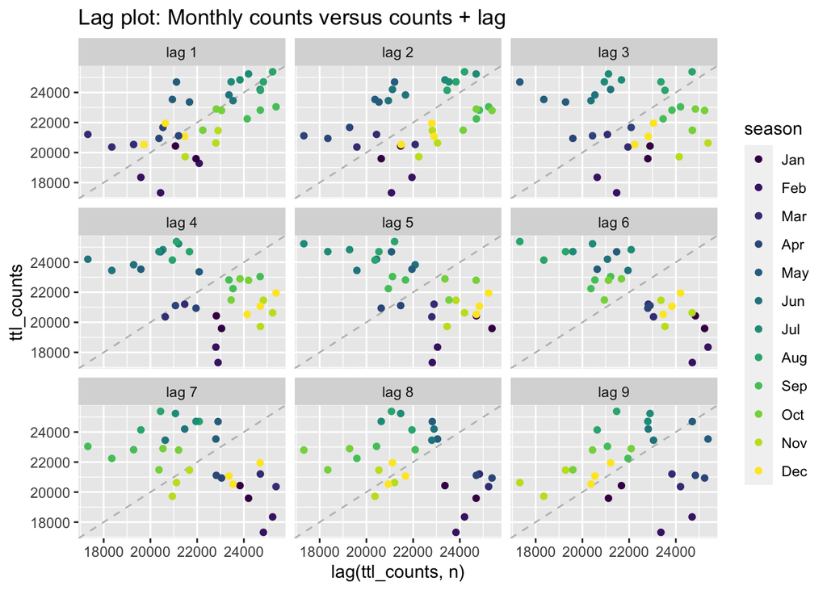

```r
daily_crime %>%
  filter(between(year(date), 2017, 2019)) %>%
  index_by(year_month = ~ yearmonth(.)) %>% # monthly aggregates
    summarise(
      ttl_counts = sum(counts, na.rm = TRUE)
    ) %>%
  gg_lag(ttl_counts, geom="point") +
  ggtitle("Lag plot: Monthly counts versus counts + lag")
```

## Autocorrelation

Correlation measures the extent of a linear relationship between two variables. Autocorrelation measures the linear relationship between lagged values of a time series. The autocorrelation coefficients make up the autocorrelation function or ACF. In simple words: how do counts between months correlate?

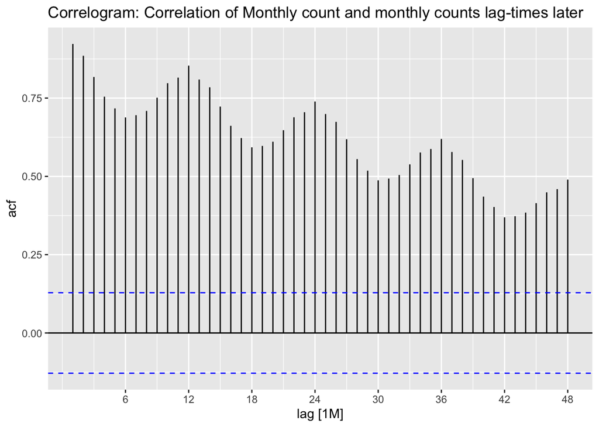

```r
daily_crime %>%
  index_by(year_month = ~ yearmonth(.)) %>% # monthly aggregates
    summarise(
      ttl_counts = sum(counts, na.rm = TRUE)
    ) %>%
  ACF(ttl_counts, lag_max = 48) %>% autoplot() +
  ggtitle("Correlogram: Correlation of Monthly count and monthly counts lag-times later")
```

The monthly offense counts are strongly autocorrelated. We notice both the seasonal trend and negative trend. Neighboring monthly counts are stronger correlated than those shifted by 6-month. The larger the lag, the weaker the correlation.

### Time Series Decomposition